# EDA_Netfilx

### **Table of Content:-**

1. Import libraries
2. Read the dataset file
3. Show a brief of the dataframe
4. Data Exploration
5. EDA Questions
6. Conclusion

### 1- Import libraries

```python
import pandas as pd
import numpy as np
import matplotlib.pyplot as plt
import seaborn as sns
```

### 2- Read the dataset file

```python
## the Dataframe we will call as nflx
nflx = pd.read_csv(r'C:\Users\dell\Desktop\DATA_ SCIENCE\data_sets\kaggleDS\netfilx\net.csv')
```

### 3- Show abrief of dataframe

```python
## show first 10 rows with all columns
nflx.head(10)
```

|  | show_id | type | title | director | country | date_added | release_year | rating | duration | listed_in |
| --- | --- | --- | --- | --- | --- | --- | --- | --- | --- | --- |
| 0 | s1 | Movie | Dick Johnson Is Dead | Kirsten Johnson | United States | 9/25/2021 | 2020 | PG-13 | 90 min | Documentaries |
| 1 | s3 | TV Show | Ganglands | Julien Leclercq | France | 9/24/2021 | 2021 | TV-MA | 1 Season | Crime TV Shows, International TV Shows, TV Act... |
| 2 | s6 | TV Show | Midnight Mass | Mike Flanagan | United States | 9/24/2021 | 2021 | TV-MA | 1 Season | TV Dramas, TV Horror, TV Mysteries |
| 3 | s14 | Movie | Confessions of an Invisible Girl | Bruno Garotti | Brazil | 9/22/2021 | 2021 | TV-PG | 91 min | Children & Family Movies, Comedies |
| 4 | s8 | Movie | Sankofa | Haile Gerima | United States | 9/24/2021 | 1993 | TV-MA | 125 min | Dramas, Independent Movies, International Movies |
| 5 | s9 | TV Show | The Great British Baking Show | Andy Devonshire | United Kingdom | 9/24/2021 | 2021 | TV-14 | 9 Seasons | British TV Shows, Reality TV |
| 6 | s10 | Movie | The Starling | Theodore Melfi | United States | 9/24/2021 | 2021 | PG-13 | 104 min | Comedies, Dramas |
| 7 | s939 | Movie | Motu Patlu in the Game of Zones | Suhas Kadav | India | 5/1/2021 | 2019 | TV-Y7 | 87 min | Children & Family Movies, Comedies, Music & Mu... |
| 8 | s13 | Movie | Je Suis Karl | Christian Schwochow | Germany | 9/23/2021 | 2021 | TV-MA | 127 min | Dramas, International Movies |
| 9 | s940 | Movie | Motu Patlu in Wonderland | Suhas Kadav | India | 5/1/2021 | 2013 | TV-Y7 | 76 min | Children & Family Movies, Music & Musicals |

```python
## show last 10 rows with all columns
nflx.tail(10)
```

|  | show_id | type | title | director | country | date_added | release_year | rating | duration | listed_in |
| --- | --- | --- | --- | --- | --- | --- | --- | --- | --- | --- |
| 8780 | s8759 | TV Show | World's Busiest Cities | Not Given | United Kingdom | 2/1/2019 | 2017 | TV-PG | 1 Season | British TV Shows, Docuseries |
| 8781 | s8776 | TV Show | Yeh Meri Family | Not Given | India | 8/31/2018 | 2018 | TV-PG | 1 Season | International TV Shows, TV Comedies |
| 8782 | s8781 | TV Show | Yo-Kai Watch | Not Given | United States | 4/1/2016 | 2015 | TV-Y7 | 1 Season | Anime Series, Kids' TV |
| 8783 | s8785 | Movie | Yoko and His Friends | Not Given | Russia | 6/23/2018 | 2015 | TV-Y | 78 min | Children & Family Movies |
| 8784 | s8796 | TV Show | Yu-Gi-Oh! Arc-V | Not Given | Japan | 5/1/2018 | 2015 | TV-Y7 | 2 Seasons | Anime Series, Kids' TV |
| 8785 | s8797 | TV Show | Yunus Emre | Not Given | Turkey | 1/17/2017 | 2016 | TV-PG | 2 Seasons | International TV Shows, TV Dramas |
| 8786 | s8798 | TV Show | Zak Storm | Not Given | United States | 9/13/2018 | 2016 | TV-Y7 | 3 Seasons | Kids' TV |
| 8787 | s8801 | TV Show | Zindagi Gulzar Hai | Not Given | Pakistan | 12/15/2016 | 2012 | TV-PG | 1 Season | International TV Shows, Romantic TV Shows, TV ... |
| 8788 | s8784 | TV Show | Yoko | Not Given | Pakistan | 6/23/2018 | 2016 | TV-Y | 1 Season | Kids' TV |
| 8789 | s8786 | TV Show | YOM | Not Given | Pakistan | 6/7/2018 | 2016 | TV-Y7 | 1 Season | Kids' TV |

### 4- Data Exploration :-

```python
## the shape of data Rows and columns
nflx.shape
```

```
(8790, 10)
```

```python
## the size of dataset
nflx.size
```

```
87900
```

```python
## get more information about the dataset
nflx.info()
```

```
<class 'pandas.core.frame.DataFrame'>
RangeIndex: 8790 entries, 0 to 8789
Data columns (total 10 columns):
 #   Column        Non-Null Count  Dtype
---  ------        --------------  -----
 0   show_id       8790 non-null   object
 1   type          8790 non-null   object
 2   title         8790 non-null   object
 3   director      8790 non-null   object
 4   country       8790 non-null   object
 5   date_added    8790 non-null   object
 6   release_year  8790 non-null   int64
 7   rating        8790 non-null   object
 8   duration      8790 non-null   object
 9   listed_in     8790 non-null   object
dtypes: int64(1), object(9)
memory usage: 686.8+ KB
```

**We found that the data is consist of 8790 row and 10 columns , The Data Types ara object 'string' except (release_year) is numerical variable**

```python
## there are not any missing values
nflx.isna().any()
```

```
show_id         False
type            False
title           False
director        False
country         False
date_added      False
release_year    False
rating          False
duration        False
listed_in       False
dtype: bool
```

```python
## the columns of dataset
nflx.columns
```

```
Index(['show_id', 'type', 'title', 'director', 'country', 'date_added',
       'release_year', 'rating', 'duration', 'listed_in'],
      dtype='object')
```

```python
## get more statistical information about numerical data
nflx.describe()
```

|  | release_year |
| --- | --- |
| count | 8790.000000 |
| mean | 2014.183163 |
| std | 8.825466 |
| min | 1925.000000 |
| 25% | 2013.000000 |
| 50% | 2017.000000 |
| 75% | 2019.000000 |
| max | 2021.000000 |

```python
##Finding how many unique values are in the dataset
nflx.nunique()
```

```
show_id         8790
type               2
title           8787
director        4528
country           86
date_added      1713
release_year      74
rating            14
duration         220
listed_in        513
dtype: int64
```

### 5- EDA Questions :-

#### 5.1- What different types of show or movie are uploaded on Netflix?

```python
## check the types of netfilx content
nflx['type'].unique()
```

```
array(['Movie', 'TV Show'], dtype=object)
```

**the Dataset is (Movie or TV show )**

```python
nflx['type'].value_counts()
```

```
type
Movie      6126
TV Show    2664
Name: count, dtype: int64
```

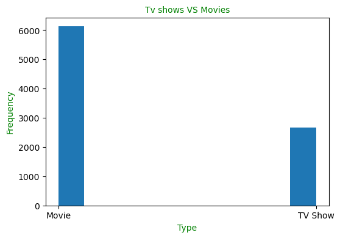

```python
## Visualize the types of netfix content

plt.figure(figsize=(6,4))  ## the figure size

plt.hist(nflx['type'],bins=10)     ## plot a Histogram

plt.title("Tv shows VS Movies", color='green', fontsize=10)
plt.xlabel("Type", color='green', fontsize=10)
plt.ylabel("Frequency", color='green', fontsize=10)
plt.show()
```

[figure not shown]

```python
## Visualize the types of netfix content in pie chart
type_show = ['Movie','TV Show']
Value_count = [5522,178]
plt.pie(Value_count,labels=type_show,autopct="%2.2f%%")
plt.legend(title='Most watched shows on the Netflix')
plt.show()
```

**We will deduce from that the following : _ the Movies is more than Tv showes on Netfilx**

#### 5.2- What is the best TV show on Netflix in 2021?

```python
## print all Tv shows on Netfilx
nflx[nflx['type'] == 'TV Show']
```

|  | show_id | type | title | director | country | date_added | release_year | rating | duration | listed_in |
| --- | --- | --- | --- | --- | --- | --- | --- | --- | --- | --- |
| 1 | s3 | TV Show | Ganglands | Julien Leclercq | France | 9/24/2021 | 2021 | TV-MA | 1 Season | Crime TV Shows, International TV Shows, TV Act... |
| 2 | s6 | TV Show | Midnight Mass | Mike Flanagan | United States | 9/24/2021 | 2021 | TV-MA | 1 Season | TV Dramas, TV Horror, TV Mysteries |
| 5 | s9 | TV Show | The Great British Baking Show | Andy Devonshire | United Kingdom | 9/24/2021 | 2021 | TV-14 | 9 Seasons | British TV Shows, Reality TV |
| 17 | s4 | TV Show | Jailbirds New Orleans | Not Given | Pakistan | 9/24/2021 | 2021 | TV-MA | 1 Season | Docuseries, Reality TV |
| 18 | s15 | TV Show | Crime Stories: India Detectives | Not Given | Pakistan | 9/22/2021 | 2021 | TV-MA | 1 Season | British TV Shows, Crime TV Shows, Docuseries |
| ... | ... | ... | ... | ... | ... | ... | ... | ... | ... | ... |
| 8785 | s8797 | TV Show | Yunus Emre | Not Given | Turkey | 1/17/2017 | 2016 | TV-PG | 2 Seasons | International TV Shows, TV Dramas |
| 8786 | s8798 | TV Show | Zak Storm | Not Given | United States | 9/13/2018 | 2016 | TV-Y7 | 3 Seasons | Kids' TV |
| 8787 | s8801 | TV Show | Zindagi Gulzar Hai | Not Given | Pakistan | 12/15/2016 | 2012 | TV-PG | 1 Season | International TV Shows, Romantic TV Shows, TV ... |
| 8788 | s8784 | TV Show | Yoko | Not Given | Pakistan | 6/23/2018 | 2016 | TV-Y | 1 Season | Kids' TV |
| 8789 | s8786 | TV Show | YOM | Not Given | Pakistan | 6/7/2018 | 2016 | TV-Y7 | 1 Season | Kids' TV |

2664 rows × 10 columns

```python
## the number of rating
nflx['rating'].nunique()
```

```
14
```

```python
## The Rating valuse
nflx['rating'].value_counts()
```

```
rating
TV-MA       3205
TV-14       2157
TV-PG        861
R            799
PG-13        490
TV-Y7        333
TV-Y         306
PG           287
TV-G         220
NR            79
G             41
TV-Y7-FV       6
NC-17          3
UR             3
Name: count, dtype: int64
```

**The rating system used by Netflix is as follows, from least to most restrictive:_**

1. TV-Y (appropriate for all children)
2. TV-Y7 (appropriate for children age 7 and above)
3. TV-Y7-FV (appropriate for children age 7 and above, with fantasy or cartoon violence)
4. TV-G (appropriate for general audiences)
5. TV-PG (parental guidance suggested)
6. PG (parental guidance suggested)
7. PG-13 (may be inappropriate for children under 13)
8. TV-14 (may be inappropriate for children under 14)
9. TV-MA (mature audiences only)
10. R (restricted; under 17 requires accompanying parent or adult guardian)
11. NC-17 (no one 17 and under admitted)
12. UR (unrated)
13. NR (not rated)

**that mean TV-MA is the highest rating for Tv shows** AND **NC-17 is the highest rating for Movies**

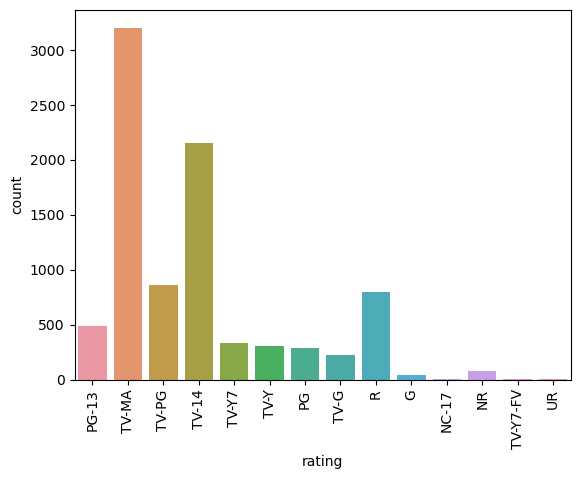

```python
## visualize the all rating
sns.countplot(x=nflx['rating'],orient='v')
plt.xticks(rotation=90)
plt.show()
```

**That mean the TV-MA is the most high rating TV show on Netfilx**

```python
## show all Tv Showes which have the most high rating (TV-MA) in 2021
nflx[(nflx['type'] == 'TV Show') & (nflx['rating']=='TV-MA') & (nflx['release_year']==2021) ]
```

|  | show_id | type | title | director | country | date_added | release_year | rating | duration | listed_in |
| --- | --- | --- | --- | --- | --- | --- | --- | --- | --- | --- |
| 1 | s3 | TV Show | Ganglands | Julien Leclercq | France | 9/24/2021 | 2021 | TV-MA | 1 Season | Crime TV Shows, International TV Shows, TV Act... |
| 2 | s6 | TV Show | Midnight Mass | Mike Flanagan | United States | 9/24/2021 | 2021 | TV-MA | 1 Season | TV Dramas, TV Horror, TV Mysteries |
| 17 | s4 | TV Show | Jailbirds New Orleans | Not Given | Pakistan | 9/24/2021 | 2021 | TV-MA | 1 Season | Docuseries, Reality TV |
| 18 | s15 | TV Show | Crime Stories: India Detectives | Not Given | Pakistan | 9/22/2021 | 2021 | TV-MA | 1 Season | British TV Shows, Crime TV Shows, Docuseries |
| 24 | s12 | TV Show | Bangkok Breaking | Kongkiat Komesiri | Not Given | 9/23/2021 | 2021 | TV-MA | 1 Season | Crime TV Shows, International TV Shows, TV Act... |
| ... | ... | ... | ... | ... | ... | ... | ... | ... | ... | ... |
| 6907 | s1428 | TV Show | Inside the World’s Toughest Prisons | Not Given | United Kingdom | 1/8/2021 | 2021 | TV-MA | 5 Seasons | British TV Shows, Crime TV Shows, Docuseries |
| 6911 | s1438 | TV Show | Surviving Death | Not Given | United States | 1/6/2021 | 2021 | TV-MA | 1 Season | Docuseries, Reality TV |
| 6912 | s1440 | TV Show | History of Swear Words | Not Given | United States | 1/5/2021 | 2021 | TV-MA | 1 Season | Docuseries, TV Comedies |
| 6920 | s1461 | TV Show | Monarca | Not Given | Mexico | 1/1/2021 | 2021 | TV-MA | 2 Seasons | International TV Shows, Spanish-Language TV Sh... |
| 7355 | s2921 | TV Show | Love Is Blind | Not Given | United States | 2/13/2020 | 2021 | TV-MA | 1 Season | Reality TV, Romantic TV Shows |

160 rows × 10 columns

```python
## show all Tv Showes which have the most high rating (TV-MA) in 2021
nflx[(nflx['type'] == 'TV Show') & (nflx['rating']=='TV-MA') & (nflx['release_year']==2021)].nunique()
```

```
show_id         160
type              1
title           160
director         29
country          29
date_added       96
release_year      1
rating            1
duration          6
listed_in        62
dtype: int64
```

#### from the previous knewledge we knew that the highest rating for movies is NC-17

```python
nflx[(nflx['type']=='Movie') & (nflx['rating']=='NC-17')]
```

|  | show_id | type | title | director | country | date_added | release_year | rating | duration | listed_in |
| --- | --- | --- | --- | --- | --- | --- | --- | --- | --- | --- |
| 3782 | s5265 | Movie | Swearnet: The Movie | Warren P. Sonoda | Canada | 9/24/2017 | 2014 | NC-17 | 112 min | Comedies, International Movies |
| 4574 | s6339 | Movie | Blue Is the Warmest Color | Abdellatif Kechiche | France | 8/26/2016 | 2013 | NC-17 | 180 min | Dramas, Independent Movies, International Movies |
| 8533 | s7264 | Movie | Lady-Like | Not Given | United States | 1/18/2019 | 2018 | NC-17 | 83 min | Comedies, Independent Movies |

### 5.4- What is the country which have the biggest number of content on Netfix?

```python
## check how many counries in dataset
nflx['country'].nunique()
```

```
86
```

```python
## print all countries in dataset
nflx['country'].unique()
```

```
array(['United States', 'France', 'Brazil', 'United Kingdom', 'India',
       'Germany', 'Pakistan', 'Not Given', 'China', 'South Africa',
       'Japan', 'Nigeria', 'Spain', 'Philippines', 'Australia',
       'Argentina', 'Canada', 'Hong Kong', 'Italy', 'New Zealand',
       'Egypt', 'Colombia', 'Mexico', 'Belgium', 'Switzerland', 'Taiwan',
       'Bulgaria', 'Poland', 'South Korea', 'Saudi Arabia', 'Thailand',
       'Indonesia', 'Kuwait', 'Malaysia', 'Vietnam', 'Lebanon', 'Romania',
       'Syria', 'United Arab Emirates', 'Sweden', 'Mauritius', 'Austria',
       'Turkey', 'Czech Republic', 'Cameroon', 'Netherlands', 'Ireland',
       'Russia', 'Kenya', 'Chile', 'Uruguay', 'Bangladesh', 'Portugal',
       'Hungary', 'Norway', 'Singapore', 'Iceland', 'Serbia', 'Namibia',
       'Peru', 'Mozambique', 'Ghana', 'Zimbabwe', 'Israel', 'Finland',
       'Denmark', 'Paraguay', 'Cambodia', 'Georgia', 'Soviet Union',
       'Greece', 'West Germany', 'Iran', 'Venezuela', 'Slovenia',
       'Guatemala', 'Jamaica', 'Somalia', 'Croatia', 'Jordan',
       'Luxembourg', 'Senegal', 'Belarus', 'Puerto Rico', 'Cyprus',
       'Ukraine'], dtype=object)
```

```python
nflx['country'].value_counts()
```

```
country
United States     3240
India             1057
United Kingdom     638
Pakistan           421
Not Given          287
                  ...
Iran                 1
West Germany         1
Greece               1
Zimbabwe             1
Soviet Union         1
Name: count, Length: 86, dtype: int64
```

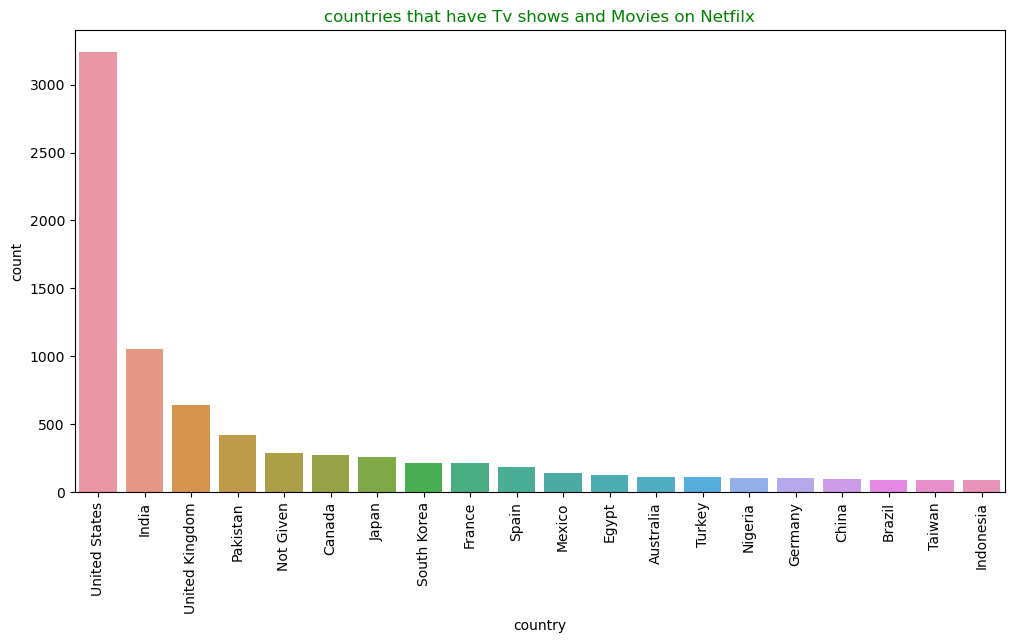

```python
## Visuallize the Countries

plt.figure(figsize=(12,6))

sns.countplot(x='country', data=nflx, order=nflx['country'].value_counts().index[:20])

plt.title("countries that have Tv shows and Movies on Netfilx", color='g')
plt.xticks(rotation=90)
plt.show()
```

**It is mean That United States have the biggest number of shows on Netflix**

### 5.5- What is the Top 5 popular categories on Netfilx?

```python
## check the valuses of listed_in
nflx['listed_in'].value_counts()
```

```
listed_in
Dramas, International Movies                                362
Documentaries                                               359
Stand-Up Comedy                                             334
Comedies, Dramas, International Movies                      274
Dramas, Independent Movies, International Movies            252
                                                           ...
Anime Features                                                1
Action & Adventure, Horror Movies, Independent Movies         1
Action & Adventure, Classic Movies, International Movies      1
Cult Movies, Independent Movies, Thrillers                    1
Classic & Cult TV, Crime TV Shows, TV Dramas                  1
Name: count, Length: 513, dtype: int64
```

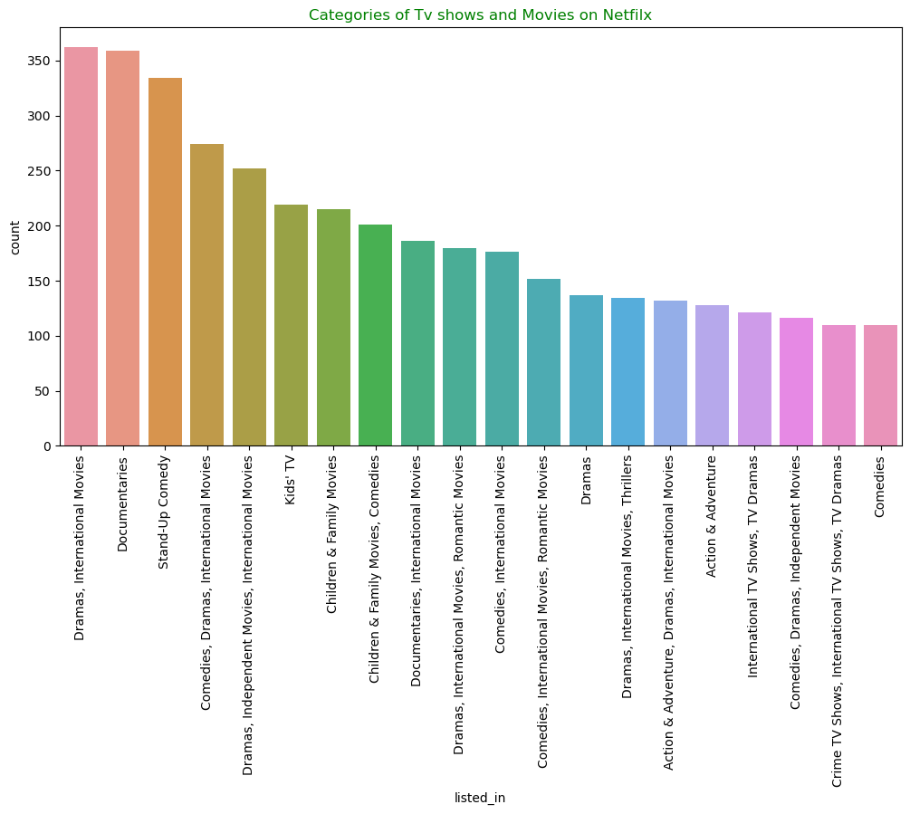

```python
## Visuallize the categories

plt.figure(figsize=(12,6))

sns.countplot(x='listed_in', data=nflx, order=nflx['listed_in'].value_counts().index[:20])

plt.title("Categories of Tv shows and Movies on Netfilx", color='g')
plt.xticks(rotation=90)
plt.show()
```

### 5.6- What is the most watched show based on the Duration?

```python
## there are 220 different duration time
nflx['duration'].nunique()
```

```
220
```

```python
nflx['duration'].value_counts()
```

```
duration
1 Season      1791
2 Seasons      421
3 Seasons      198
90 min         152
97 min         146
              ...
5 min            1
16 min           1
186 min          1
193 min          1
11 Seasons       1
Name: count, Length: 220, dtype: int64
```

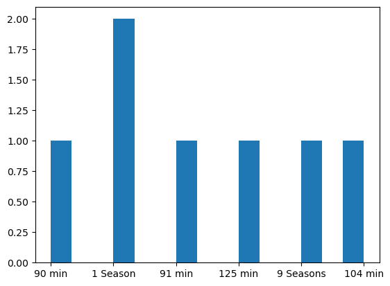

```python
## visuallize the Duration times of top seven tv-show or movies
x = nflx['duration'].head(7)
plt.hist(x, bins=15)
plt.show()
```

```python
nflx[(nflx['duration']=='9 Seasons') & (nflx['type']=='TV Show')]
```

|  | show_id | type | title | director | country | date_added | release_year | rating | duration | listed_in |
| --- | --- | --- | --- | --- | --- | --- | --- | --- | --- | --- |
| 5 | s9 | TV Show | The Great British Baking Show | Andy Devonshire | United Kingdom | 9/24/2021 | 2021 | TV-14 | 9 Seasons | British TV Shows, Reality TV |
| 551 | s6505 | TV Show | Club Friday The Series 6 | Not Given | Pakistan | 3/9/2019 | 2015 | TV-MA | 9 Seasons | International TV Shows, Romantic TV Shows, TV ... |
| 1689 | s1999 | TV Show | Call the Midwife | Philippa Lowthorpe | United Kingdom | 9/15/2020 | 2020 | TV-MA | 9 Seasons | British TV Shows, International TV Shows, TV D... |
| 2690 | s3542 | TV Show | Naruto | Hayato Date | Japan | 9/1/2019 | 2006 | TV-14 | 9 Seasons | Anime Series, International TV Shows |
| 6584 | s68 | TV Show | Saved by the Bell | Not Given | United States | 9/15/2021 | 1994 | TV-PG | 9 Seasons | Kids' TV, TV Comedies |
| 6927 | s1481 | TV Show | Still Game | Not Given | United Kingdom | 12/30/2020 | 2018 | TV-14 | 9 Seasons | British TV Shows, Classic & Cult TV, Internati... |
| 6995 | s1702 | TV Show | American Horror Story | Not Given | United States | 11/13/2020 | 2019 | TV-MA | 9 Seasons | TV Horror, TV Mysteries, TV Thrillers |
| 8277 | s5804 | TV Show | Forensic Files | Not Given | United States | 9/1/2016 | 2011 | TV-MA | 9 Seasons | Crime TV Shows, Docuseries, Science & Nature TV |
| 8735 | s8443 | TV Show | The Office (U.S.) | Not Given | United States | 1/1/2016 | 2012 | TV-14 | 9 Seasons | TV Comedies |

### 6- Conclusion :-

-We explore the Netflix dataset and learn more about data attributes then jump into how to visualize the data with Exploratory Data Analysis. -We saw some basic and advanced level charts of seaborn and matplotlib like (Pie-chart, Bar chart, Countplot).

- The questions were answeres within the Analysis: _

-What different types of show or movie are uploaded on Netflix? -What is the best TV show on Netflix in 2021? -what is the highest rating Tv show or Movies in dataset? -What is the best Movie on Netfilx in 2021? -what is the Top 5 popular categories on Netfilx? -what is the country which have the biggest number of content on Netfix? -What is the most watched show based on the Duration?

Thank You, Happy to get any suggestions or feedbacks